# SGL Growth Models

Drew Walker

21 April, 2022

**This study aims to assess the effects of virtual social events on Streetlight Gaming and Online Team patient, volunteer, and staff comments on Discord.**

We also keep detailed event logs, documenting when events in the server are facilitated and which players attended.

# Model Building

- **Outcome**: User daily comments in Discord (recent comments)
- **Level 1 Predictors**:
  - Time/Individual repeated measures (Days in Discord)
  - What about days since Discord started (for each date? equal across all users)
  - Number of days since comment pull?
- **Level 2 Predictors**:
  - Patient, Volunteer, or Staff status,
- **Level 3 Predictor**:
  - Number of overall users in Discord
  - number of comments in overall server on that day
  - Number of days since comment was last pulled that day?
- **Level 4 Predictors**:
  - Presence of an event during that day
  - Presence of seasonal event that day.

Data Description

Although the data is daily comment totals, it is not regularly spaced in timed intervals– we run the code when we are able to on weekdays, but due to concerns for patient data, we cannot schedule the code to be run every day on a server

- Average day difference ?

Events are also not occurring at regular intervals– we schedule them at the discretion of staff or patient need. I’m hoping this project, framed as a quality improvement effort, will help program staff understand the value in these events at driving community engagement, and be willing to justify allocation of funds to these key moderator roles.

# Load in data from REDCap/last SGL data pull

https://rpsychologist.com/r-guide-longitudinal-lme-lmer

```r
library(haven)
load("sgl_comments_data.Rda")

# output for hlm to get equation
hlm_snip <- firstday_set_filtered %>%
  head(n = 600)

write_csv(hlm_snip, "sgl_snip.csv")
# Extra fun bc hlm doesn't work well with csv?
write.dta(hlm_snip, "sgl_snip.dta")
tmp <- tempfile(fileext = ".xpt")
write_xpt(hlm_snip, tmp)
write_sav(hlm_snip, "hlm_snip.sav")


library(nlme)
library(lme4)
#firstday_set$days_since_discord_first_comment<- #as.numeric(str_remove(firstday_set$days_since_discord_first_comme#nt, " days"))
#firstday_set$record_id <- as.factor(firstday_set$record_id)

# After first visualization, realize we need to remove data from 2019-01-24, because it caught existing discord users who were in server prior to data being collected.

# Also after 2019-09-16 due to error in code that produced negative value
#firstday_set_filtered <- firstday_set %>%
#  filter(date != "2019-01-24") %>%
#  filter(date !="2019-09-16") %>%
#  left_join(daily_summaries, by = "date")

#save(firstday_set_filtered,file="sgl_comments_data.Rda")

sgl_descriptives_df <- firstday_set_filtered %>%
  distinct(record_id,status, .keep_all = TRUE)

date_list <- as.factor(firstday_set_filtered$date)

unique_date_list <- as.character(date_list) %>%
  unique() %>%
  as.Date()

TotalCommentStatusSummary <- firstday_set_filtered %>%
  filter(date == "2022-01-19") %>%
  group_by(status) %>%
  summarise(status_message_count = sum(message_count))
TotalCommentStatusSummary <- TotalCommentStatusSummary %>%
  ungroup() %>%
  mutate(total_messages = sum(status_message_count),
         percentage_messages = ((status_message_count/total_messages)*100))

#Tables
totalstatustable <- gt(TotalCommentStatusSummary)
totalstatustable
```

| status | status_message_count | total_messages | percentage_messages |
| --- | --- | --- | --- |
| Patient | 16532 | 26284 | 62.89758 |
| Staff | 5782 | 26284 | 21.99817 |
| Volunteer | 3970 | 26284 | 15.10425 |

```r
sgl_descriptives_df$status <- as.factor(sgl_descriptives_df$status)
table1(~status, data = sgl_descriptives_df)
```

|  | Overall (N=167) |
| --- | --- |
| status |  |
| Patient | 98.0 (58.7%) |
| Staff | 6.00 (3.6%) |
| Volunteer | 63.0 (37.7%) |

```r
# Recent comments by status
table1(~recent_comments|status, data = firstday_set_filtered)
```

|  | Patient (N=41206) | Staff (N=3950) | Volunteer (N=26569) | Overall (N=71725) |
| --- | --- | --- | --- | --- |
| recent_comments |  |  |  |  |
| Mean (SD) | 0.389 (2.67) | 1.34 (4.42) | 0.141 (1.19) | 0.350 (2.40) |
| Median [Min, Max] | 0 [0, 155] | 0 [0, 63.0] | 0 [0, 80.0] | 0 [0, 155] |

```r
days_since_df <- firstday_set_filtered %>%
  filter(date == "2022-01-19") %>%
  distinct(record_id, .keep_all = TRUE)
table1(~days_since_discord_first_comment|status, data = days_since_df)
```

|  | Patient (N=98) | Staff (N=6) | Volunteer (N=63) | Overall (N=167) |
| --- | --- | --- | --- | --- |
| days_since_discord_first_comment |  |  |  |  |
| Mean (SD) | 653 (364) | 798 (337) | 692 (382) | 673 (369) |
| Median [Min, Max] | 721 [39.0, 1090] | 881 [351, 1090] | 820 [39.0, 1090] | 721 [39.0, 1090] |
| Missing | 2.00 (2.0%) | 0 (0%) | 0 (0%) | 2.00 (1.2%) |

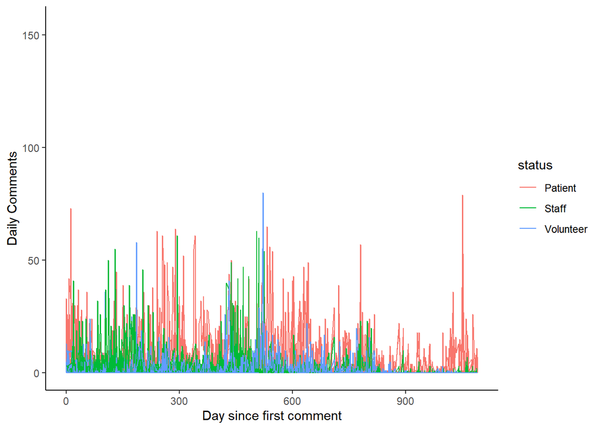

```r
# Now we joined daily overall server summaries, which gives us
# users in discord, day's total discord comments, and active users
# Plot LOESS curve

plot_obs <- ggplot(data=firstday_set_filtered,
                   aes(x = days_since_discord_first_comment,
                       y = recent_comments, group = record_id,color=status))+
  geom_line()+
  #adding lines to plot
                   theme_classic() +
  scale_x_continuous(name = "Day since first comment")+
                   scale_y_continuous(name = "Daily Comments")
plot_obs
```

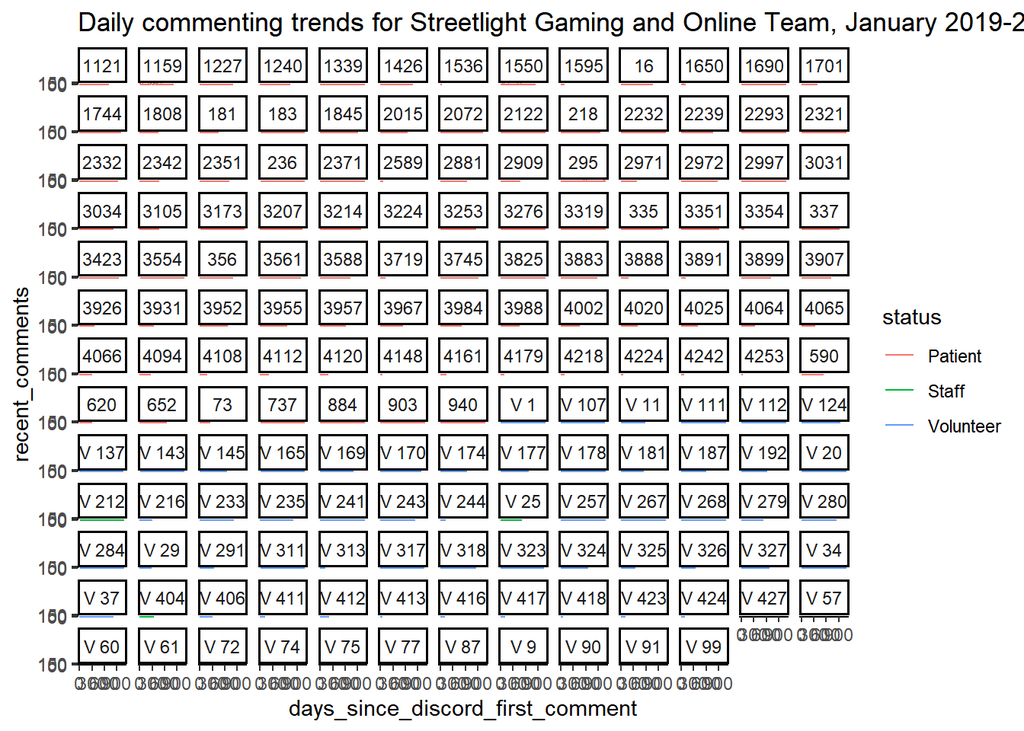

```r
plot_facet <- ggplot(data = firstday_set_filtered, aes(days_since_discord_first_comment,recent_comments))+
         geom_line(aes(color = status))+
  ggtitle('Daily commenting trends for Streetlight Gaming and Online Team, January 2019-2022')+
  theme_classic() +
  facet_wrap(~ record_id)
plot_facet
```

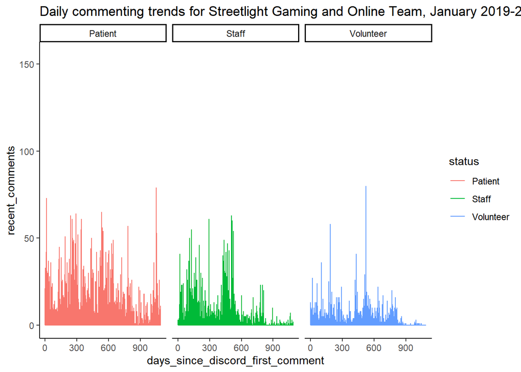

```r
ggsave('sgl_facet.png', width = 50, height = 50, units = "in", limitsize = FALSE)

# Facet by status

plot_facet_status <- ggplot(data = firstday_set_filtered, aes(days_since_discord_first_comment,recent_comments))+
         geom_line(aes(color = status))+
  ggtitle('Daily commenting trends for Streetlight Gaming and Online Team, January 2019-2022')+
  theme_classic() +
  facet_wrap(~ status)
plot_facet_status
```

```r
ggsave('sgl_facet_status.png', width = 10, height = 10, units = "in", limitsize = FALSE)
null <- lme(recent_comments ~ days_since_discord_first_comment*status, random = ~ days_since_discord_first_comment | record_id, data=firstday_set_filtered, na.action = na.omit)

summary(null)
```

```
## Linear mixed-effects model fit by REML
##  Data: firstday_set_filtered
##        AIC      BIC    logLik
##   307326.6 307418.3 -153653.3
##
## Random effects:
##  Formula: ~days_since_discord_first_comment | record_id
##  Structure: General positive-definite, Log-Cholesky parametrization
##                                  StdDev      Corr
## (Intercept)                      1.193178486 (Intr)
## days_since_discord_first_comment 0.002139631 -0.694
## Residual                         2.097788572
##
## Fixed effects: recent_comments ~ days_since_discord_first_comment * status
##                                                       Value Std.Error    DF
## (Intercept)                                       0.4902486 0.1240342 70707
## days_since_discord_first_comment                 -0.0005136 0.0002421 70707
## statusStaff                                       2.0697989 0.5089391   162
## statusVolunteer                                  -0.2654378 0.1969497   162
## days_since_discord_first_comment:statusStaff     -0.0016478 0.0009433 70707
## days_since_discord_first_comment:statusVolunteer  0.0002815 0.0003839 70707
##                                                    t-value p-value
## (Intercept)                                       3.952529  0.0001
## days_since_discord_first_comment                 -2.121487  0.0339
## statusStaff                                       4.066889  0.0001
## statusVolunteer                                  -1.347744  0.1796
## days_since_discord_first_comment:statusStaff     -1.746941  0.0807
## days_since_discord_first_comment:statusVolunteer  0.733292  0.4634
##  Correlation:
##                                                  (Intr) dy____ sttsSt sttsVl
## days_since_discord_first_comment                 -0.664
## statusStaff                                      -0.244  0.162
## statusVolunteer                                  -0.630  0.418  0.153
## days_since_discord_first_comment:statusStaff      0.170 -0.257 -0.690 -0.107
## days_since_discord_first_comment:statusVolunteer  0.419 -0.631 -0.102 -0.664
##                                                  d____:S
## days_since_discord_first_comment
## statusStaff
## statusVolunteer
## days_since_discord_first_comment:statusStaff
## days_since_discord_first_comment:statusVolunteer  0.162
##
## Standardized Within-Group Residuals:
##            Min             Q1            Med             Q3            Max
## -4.34686583264 -0.04095953532 -0.00705382150 -0.00004355167 37.24027515730
##
## Number of Observations: 70875
## Number of Groups: 165
```

```r
# make today be the last day of data collection
SGLPatientsREDCap <- REDCapData_Patients %>%
  group_by(record_id) %>%
  fill(bday,deceased) %>%
  mutate(team_cancer = unclass(first(project_team___1)),
    team_cf = unclass(first(project_team___2)),
    team_transplant = unclass(first(project_team___3)),
    team_sicklecell = unclass(first(project_team___4)),
    team_autoimmune = unclass(first(project_team___5)),
    team_gi = unclass(first(project_team___6)),
    team_other = unclass(first(project_team___7)),
    predicted_project_team = first(predicted_project_team)) %>%
  pivot_longer(cols = starts_with("team_"),names_to = "project_team", values_to = "team_value", values_drop_na = TRUE) %>%
  select(record_id, id,discord_user,status,bday,deceased,sgl_study_eligible,predicted_project_team,project_team,preferred_gender,team_value) %>%
  fill(discord_user,status,bday,deceased,sgl_study_eligible,predicted_project_team,project_team,preferred_gender) %>%
  filter(team_value == "2") %>%
  distinct(record_id, .keep_all = TRUE)

today <- as.Date(Sys.Date())
intervalbday <- SGLPatientsREDCap$bday %--% today
SGLPatientsREDCap$age <- intervalbday
patients_only <- sgl_descriptives_df %>%
  filter(status == "Patient")
patient_list <- patients_only %>%
  distinct(record_id)
patient_descriptives1 <- left_join(patient_list,SGLPatientsREDCap, by = "record_id")

patient_descriptives <- patient_descriptives1 %>%
  filter(is.na(deceased)|deceased != "Yes")

patient_descriptives$age <- as.numeric(patient_descriptives$age)/31536000

patient_descriptives$project_team <- as.factor(patient_descriptives$project_team)
patient_descriptives$project_team <- relevel(patient_descriptives$project_team, ref = "team_other")

table1(~age + deceased + predicted_project_team + project_team + preferred_gender, data = patient_descriptives)
```

|  | Overall (N=84) |
| --- | --- |
| age |  |
| Mean (SD) | 20.8 (4.21) |
| Median [Min, Max] | 20.0 [14.0, 35.6] |
| Missing | 1.00 (1.2%) |
| deceased |  |
| No | 83.0 (98.8%) |
| Yes | 0 (0%) |
| Missing | 1.00 (1.2%) |
| predicted_project_team |  |
| Confirmed Project Teams by Checking EPIC Diagnoses | 73.0 (86.9%) |
| Predicted Project Teams (Not yet confirmed with EPIC) | 5.00 (6.0%) |
| Missing | 6.00 (7.1%) |
| project_team |  |
| team_other | 11.0 (13.1%) |
| team_autoimmune | 10.0 (11.9%) |
| team_cancer | 16.0 (19.0%) |
| team_cf | 15.0 (17.9%) |
| team_gi | 6.00 (7.1%) |
| team_sicklecell | 7.00 (8.3%) |
| team_transplant | 19.0 (22.6%) |
| preferred_gender |  |
| Female | 13.0 (15.5%) |
| Male | 37.0 (44.0%) |
| Nonbinary | 2.00 (2.4%) |
| Missing | 32.0 (38.1%) |

# EDA Visualization

- Need to check for missingness among predictors to be able to compare models across unconditional, etc.

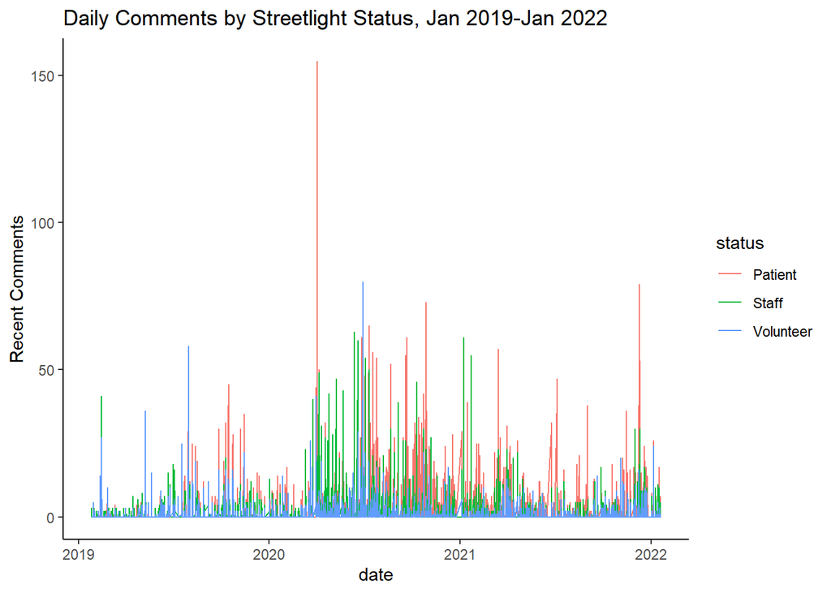

```r
plot<- ggplot(firstday_set_filtered, aes(x=date, y=recent_comments, color = status)) +
  geom_line()+
  scale_y_continuous(name="Recent Comments")+
  theme_classic()+
  ggtitle("Daily Comments by Streetlight Status, Jan 2019-Jan 2022")
plot
```

## Event list

- First, we qualitatively analyzed the event list to remove any non-patient events in the server. The SGL recruit log utilized for the events would often contain admin or server feature changes. We wanted to make sure this list was only providing data on when staff, volunteer, or patient-facilitated events occurred.
- Seasonal events
  - Summer Games
    - Need to go back and make sure we input every event and the exact dates– check Discord
    - Check for events
      - Find event for 6/3/2020
      - Find date for Jackbox Game Night (Somewhere between 1/8/2021-1/13/2021
      - May try to truncate data starting at 10/4/2019 instead to test if no time to resolve data qual issues

```r
event_log <- read_csv("DeIdentified Event log.csv")
event_log$`Event Date` <- as.Date(event_log$`Event Date`, format = "%m/%d/%Y" )

event_log_clean <- event_log %>%
  mutate(event_present = 1) %>%
  rename(date = `Event Date`)
# Seasonal events
seasonal_events <- read_csv("seasonal_events.csv")
```

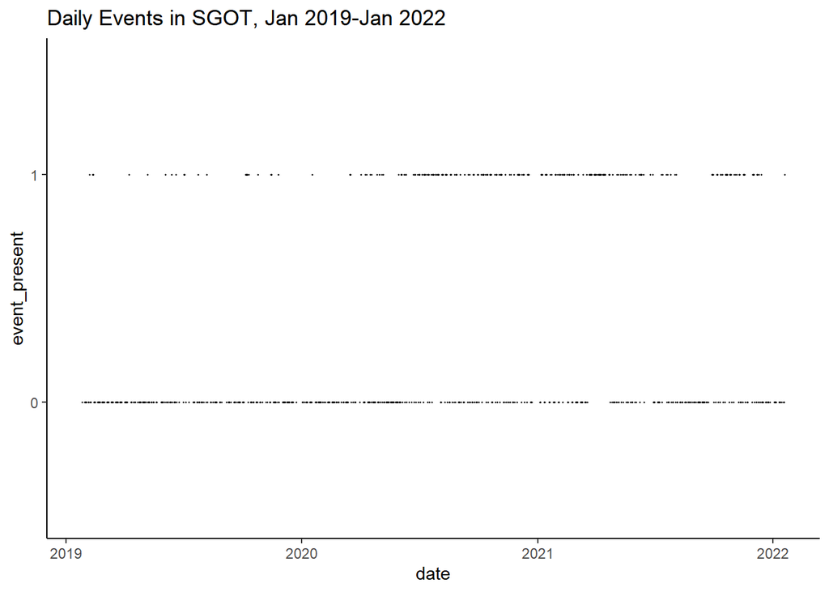

```r
seasonal_events$date <- as.Date(seasonal_events$date, format = "%m/%d/%Y" )
seasonal_events <- seasonal_events %>%
  drop_na()
#266 days of seasonal events -- where patients engaged in challenges


event_and_comment_df <- left_join(firstday_set_filtered,event_log_clean, by = "date")

# replace NA with 0 for days without events
event_and_comment_df$event_present[is.na(event_and_comment_df$event_present)] <- 0
event_and_comment_df$event_present <- as.factor(event_and_comment_df$event_present)
event_and_comment_df <- event_and_comment_df %>%
  mutate(day_of_week = wday(date),
         years_since_discord = days_since_discord_first_comment/365)

event_and_comment_df$day_of_week <- factor(event_and_comment_df$day_of_week, ordered = FALSE)

event_and_comment_df_descriptives <- left_join(event_and_comment_df,patient_descriptives, by = "record_id")
# join in seasonal events
event_and_comment_df_descriptives_2 <- left_join(event_and_comment_df_descriptives,seasonal_events, by = "date")
#make non seasonal event days 0
event_and_comment_df_descriptives_2$seasonal_event[is.na(event_and_comment_df_descriptives_2$seasonal_event)] <- 0
event_and_comment_df_descriptives_2$seasonal_event <- as.factor(event_and_comment_df_descriptives_2$seasonal_event)
event_and_comment_df_descriptives_2 <- event_and_comment_df_descriptives_2 %>%
  mutate(commented_that_day = case_when(recent_comments >0 ~ "1",
                                        TRUE ~ "0"))
patients_only1 <- event_and_comment_df_descriptives_2 %>%
  filter(status.x == "Patient") %>%
  filter(deceased != "Yes")

# Top users at 1-19-2022, assign quartiles for rank in total comments
patient_comment_total <- days_since_df %>%
  select(record_id, message_count)
patient_comment_total$quartile <- as.factor(ntile(patient_comment_total$message_count, 4))

patients_only2 <- left_join(patients_only1,patient_comment_total,by="record_id")
patients_only <- patients_only2 %>%
  mutate(years_squared = years_since_discord^2,
         years_cubed = years_since_discord^3)

event_plot <- ggplot(patients_only, aes(x=date, y=event_present)) +
  geom_point(na.rm = T,
             color = "black",
             fill = "#69b3a2",
             size = .25,
             alpha = .10)+
  theme_classic()+
  ggtitle("Daily Events in SGOT, Jan 2019-Jan 2022")
event_plot
```

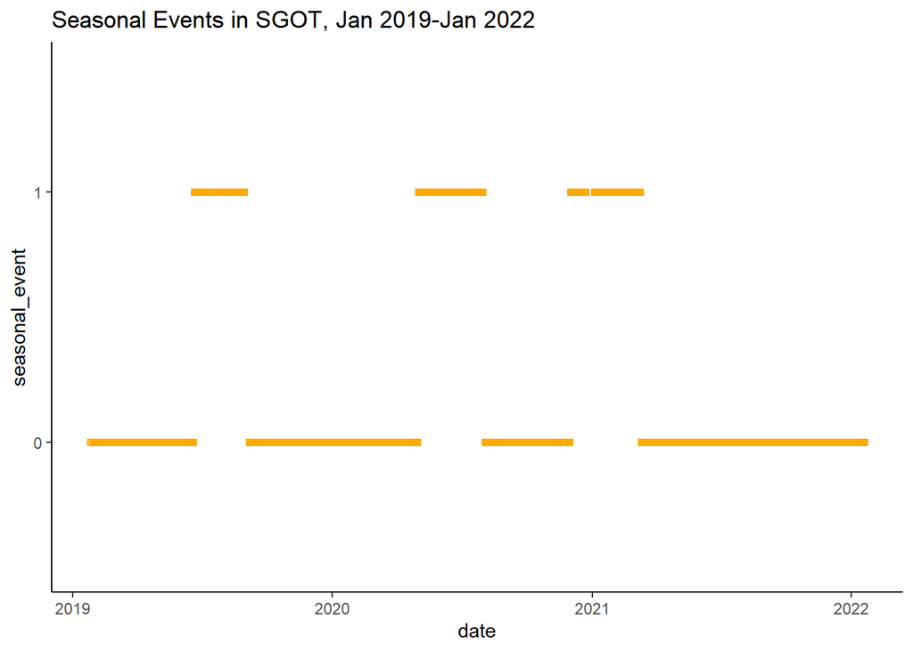

```r
seasonal_plot <- ggplot(patients_only, aes(x=date, y=seasonal_event)) +
   geom_point(na.rm = T,
             color = "orange",
             fill = "orange",
             shape = 22,
             alpha = .1)+
  theme_classic()+
    ggtitle("Seasonal Events in SGOT, Jan 2019-Jan 2022")
seasonal_plot
```

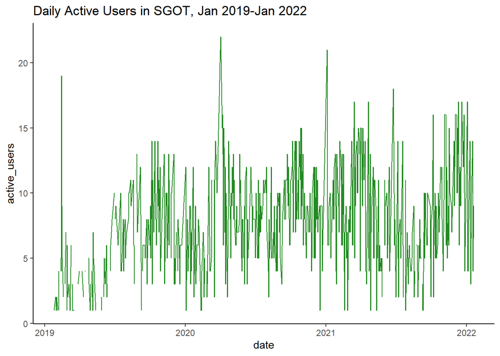

```r
active_users_plot <- ggplot(patients_only, aes(x=date, y=active_users)) +
  geom_line(color = "forest green")+
  theme_classic()+
    ggtitle("Daily Active Users in SGOT, Jan 2019-Jan 2022")
active_users_plot
```

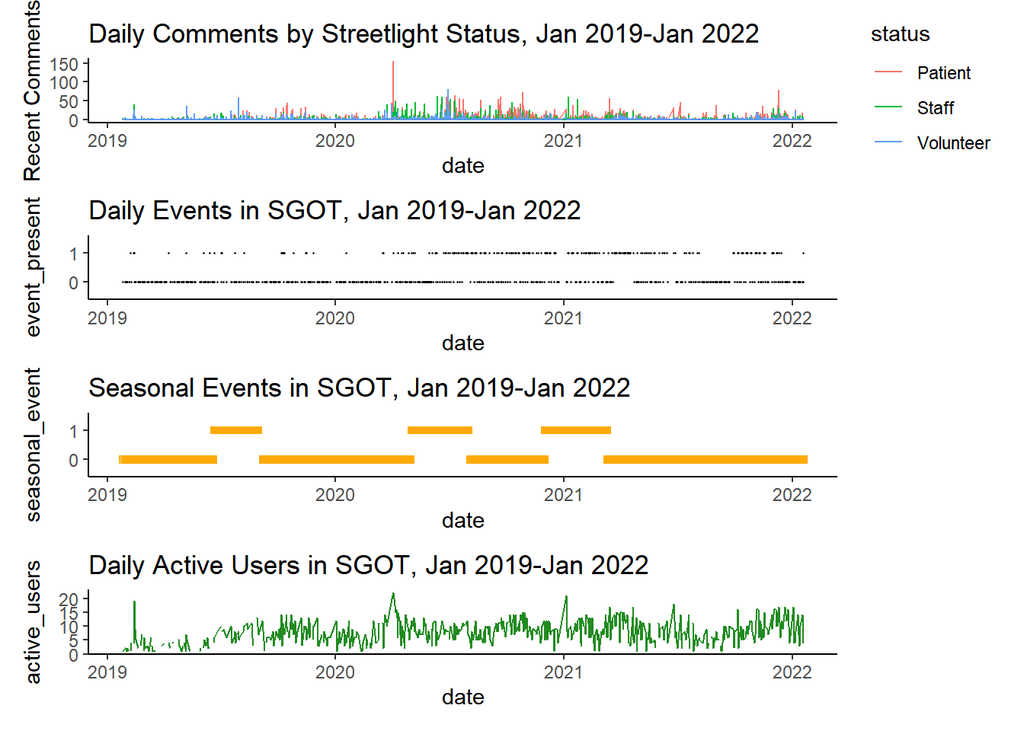

```r
library(patchwork)
plot/event_plot/seasonal_plot/active_users_plot
```

```r
ggsave('comments_and_events.png', width = 10, height = 10, units = "in", limitsize = FALSE)
```

# Unconditional Means, Unconditional Growth Models , and invididual covariate conditional growth models

```r
unconditional_means = lmer(recent_comments ∼ 1+ (1|record_id), data = patients_only, REML=FALSE)

summary(unconditional_means)
```

```
## Linear mixed model fit by maximum likelihood  ['lmerMod']
## Formula: recent_comments ~ 1 + (1 | record_id)
##    Data: patients_only
##
##      AIC      BIC   logLik deviance df.resid
## 164979.4 165004.7 -82486.7 164973.4    34677
##
## Scaled residuals:
##    Min     1Q Median     3Q    Max
## -2.488 -0.044 -0.008 -0.004 59.478
##
## Random effects:
##  Groups    Name        Variance Std.Dev.
##  record_id (Intercept) 1.084    1.041
##  Residual              6.752    2.598
## Number of obs: 34680, groups:  record_id, 83
##
## Fixed effects:
##             Estimate Std. Error t value
## (Intercept)   0.4056     0.1163   3.487
```

```r
# Unconditional growth
unconditional_growth = lmer(recent_comments ∼  years_since_discord + (years_since_discord|record_id), data = patients_only, REML=FALSE)

summary(unconditional_growth)
```

```
## Linear mixed model fit by maximum likelihood  ['lmerMod']
## Formula: recent_comments ~ years_since_discord + (years_since_discord |
##     record_id)
##    Data: patients_only
##
##      AIC      BIC   logLik deviance df.resid
## 156752.9 156803.5 -78370.5 156740.9    33786
##
## Scaled residuals:
##     Min      1Q  Median      3Q     Max
## -3.7870 -0.0490 -0.0073  0.0000 28.9553
##
## Random effects:
##  Groups    Name                Variance Std.Dev. Corr
##  record_id (Intercept)         1.9513   1.3969
##            years_since_discord 0.8916   0.9442   -0.62
##  Residual                      5.9560   2.4405
## Number of obs: 33792, groups:  record_id, 81
##
## Fixed effects:
##                     Estimate Std. Error t value
## (Intercept)           0.5099     0.1581   3.224
## years_since_discord  -0.1849     0.1181  -1.566
##
## Correlation of Fixed Effects:
##             (Intr)
## yrs_snc_dsc -0.592
```

```r
individual_covariates = lmer(recent_comments ∼  years_since_discord + age + preferred_gender + project_team + (years_since_discord|record_id), data = patients_only, REML=FALSE)

summary(individual_covariates)
```

```
## Linear mixed model fit by maximum likelihood  ['lmerMod']
## Formula: recent_comments ~ years_since_discord + age + preferred_gender +
##     project_team + (years_since_discord | record_id)
##    Data: patients_only
##
##      AIC      BIC   logLik deviance df.resid
##  81316.2  81432.5 -40643.1  81286.2    17186
##
## Scaled residuals:
##     Min      1Q  Median      3Q     Max
## -3.6328 -0.0780 -0.0097  0.0006 27.1505
##
## Random effects:
##  Groups    Name                Variance Std.Dev. Corr
##  record_id (Intercept)         2.106    1.451
##            years_since_discord 1.400    1.183    -0.63
##  Residual                      6.486    2.547
## Number of obs: 17201, groups:  record_id, 51
##
## Fixed effects:
##                               Estimate Std. Error t value
## (Intercept)                  0.2322276  1.5571076   0.149
## years_since_discord         -0.3287431  0.1966600  -1.672
## age                         -0.0160575  0.0482308  -0.333
## preferred_genderMale         0.3793509  0.4172390   0.909
## preferred_genderNonbinary    1.7125268  0.9505835   1.802
## project_teamteam_autoimmune  1.1724523  1.1036521   1.062
## project_teamteam_cancer      0.2241584  1.0849193   0.207
## project_teamteam_cf          0.2865840  1.0822080   0.265
## project_teamteam_gi          0.1237348  1.1476549   0.108
## project_teamteam_sicklecell -0.0009542  1.1074512  -0.001
## project_teamteam_transplant  0.3286909  1.0523424   0.312
##
## Correlation of Fixed Effects:
##               (Intr) yrs_s_ age    prfr_M prfr_N prjct_tmtm_tm prjct_tmtm_cn
## yrs_snc_dsc    0.017
## age           -0.730 -0.065
## prfrrd_gndM   -0.311  0.018  0.059
## prfrrd_gndN   -0.017 -0.019 -0.079  0.274
## prjct_tmtm_tm -0.735 -0.099  0.176  0.203  0.043
## prjct_tmtm_cn -0.668 -0.081  0.093  0.142 -0.143  0.848
## prjct_tmtm_cf -0.648 -0.075  0.072  0.115  0.028  0.841         0.842
## prjct_tmtm_g  -0.706 -0.091  0.180  0.164  0.031  0.824         0.812
## prjct_tmtm_s  -0.667 -0.097  0.158  0.008 -0.010  0.818         0.817
## prjct_tmtm_tr -0.690 -0.075  0.126  0.066  0.009  0.863         0.863
##               prjct_tmtm_cf prjct_tmtm_g prjct_tmtm_s
## yrs_snc_dsc
## age
## prfrrd_gndM
## prfrrd_gndN
## prjct_tmtm_tm
## prjct_tmtm_cn
## prjct_tmtm_cf
## prjct_tmtm_g   0.806
## prjct_tmtm_s   0.815         0.788
## prjct_tmtm_tr  0.860         0.829        0.846
```

```r
tab_model(unconditional_means, unconditional_growth, individual_covariates, dv.labels = c("Unconditional Means Model","Unconditional Growth", "Individual Covariates"), show.aic = TRUE, show.dev = TRUE)
```

|  | Unconditional Means Model |  |  | Unconditional Growth |  |  | Individual Covariates |  |  |
| --- | --- | --- | --- | --- | --- | --- | --- | --- | --- |
| Predictors | Estimates | CI | p | Estimates | CI | p | Estimates | CI | p |
| (Intercept) | 0.41 | 0.18 – 0.63 | **<0.001** | 0.51 | 0.20 – 0.82 | **0.001** | 0.23 | -2.82 – 3.28 | 0.881 |
| years since discord |  |  |  | -0.18 | -0.42 – 0.05 | 0.117 | -0.33 | -0.71 – 0.06 | 0.095 |
| age |  |  |  |  |  |  | -0.02 | -0.11 – 0.08 | 0.739 |
| preferred gender [Male] |  |  |  |  |  |  | 0.38 | -0.44 – 1.20 | 0.363 |
| preferred gender [Nonbinary] |  |  |  |  |  |  | 1.71 | -0.15 – 3.58 | 0.072 |
| project team [team autoimmune] |  |  |  |  |  |  | 1.17 | -0.99 – 3.34 | 0.288 |
| project team [team cancer] |  |  |  |  |  |  | 0.22 | -1.90 – 2.35 | 0.836 |
| project team [team cf] |  |  |  |  |  |  | 0.29 | -1.83 – 2.41 | 0.791 |
| project team [team gi] |  |  |  |  |  |  | 0.12 | -2.13 – 2.37 | 0.914 |
| project team [team sicklecell] |  |  |  |  |  |  | -0.00 | -2.17 – 2.17 | 0.999 |
| project team [team transplant] |  |  |  |  |  |  | 0.33 | -1.73 – 2.39 | 0.755 |
| Random Effects |  |  |  |  |  |  |  |  |  |
| σ<sup>2</sup> | 6.75 |  |  | 5.96 |  |  | 6.49 |  |  |
| τ<sub>00</sub> | 1.08 <sub>record_id</sub> |  |  | 1.95 <sub>record_id</sub> |  |  | 2.11 <sub>record_id</sub> |  |  |
| τ<sub>11</sub> |  |  |  | 0.89 <sub>record_id.years_since_discord</sub> |  |  | 1.40 <sub>record_id.years_since_discord</sub> |  |  |
| ρ<sub>01</sub> |  |  |  | -0.62 <sub>record_id</sub> |  |  | -0.63 <sub>record_id</sub> |  |  |
| ICC | 0.14 |  |  | 0.23 |  |  | 0.25 |  |  |
| N | 83 <sub>record_id</sub> |  |  | 81 <sub>record_id</sub> |  |  | 51 <sub>record_id</sub> |  |  |
| Observations | 34680 |  |  | 33792 |  |  | 17201 |  |  |
| Marginal R<sup>2</sup> / Conditional R<sup>2</sup> | 0.000 / 0.138 |  |  | 0.003 / 0.235 |  |  | 0.034 / 0.280 |  |  |
| Deviance | 164973.370 |  |  | 156740.928 |  |  | 81286.213 |  |  |
| AIC | 164979.370 |  |  | 156752.928 |  |  | 81316.213 |  |  |

# Conditional Growth Models

## Individual-level covariates

age + preferred_gender + project_team

## Event fixed

```r
event_model = lmer(recent_comments ∼  years_since_discord*event_present + (years_since_discord|record_id), data = patients_only, REML=FALSE)

summary(event_model)
```

```
## Linear mixed model fit by maximum likelihood  ['lmerMod']
## Formula:
## recent_comments ~ years_since_discord * event_present + (years_since_discord |
##     record_id)
##    Data: patients_only
##
##      AIC      BIC   logLik deviance df.resid
## 156734.3 156801.8 -78359.2 156718.3    33784
##
## Scaled residuals:
##     Min      1Q  Median      3Q     Max
## -3.7646 -0.0635 -0.0103  0.0106 28.9799
##
## Random effects:
##  Groups    Name                Variance Std.Dev. Corr
##  record_id (Intercept)         1.9467   1.3952
##            years_since_discord 0.8654   0.9303   -0.62
##  Residual                      5.9524   2.4398
## Number of obs: 33792, groups:  record_id, 81
##
## Fixed effects:
##                                    Estimate Std. Error t value
## (Intercept)                         0.43375    0.15899   2.728
## years_since_discord                -0.14765    0.11734  -1.258
## event_present1                      0.22150    0.05339   4.149
## years_since_discord:event_present1 -0.08563    0.03672  -2.332
##
## Correlation of Fixed Effects:
##             (Intr) yrs_s_ evnt_1
## yrs_snc_dsc -0.596
## evnt_prsnt1 -0.114  0.109
## yrs_snc_:_1  0.096 -0.125 -0.854
```

```r
seasonal_model = lmer(recent_comments ~ years_since_discord*seasonal_event + (years_since_discord|record_id), data = patients_only, REML=FALSE)

summary(seasonal_model)
```

```
## Linear mixed model fit by maximum likelihood  ['lmerMod']
## Formula:
## recent_comments ~ years_since_discord * seasonal_event + (years_since_discord |
##     record_id)
##    Data: patients_only
##
##      AIC      BIC   logLik deviance df.resid
## 156741.6 156809.0 -78362.8 156725.6    33784
##
## Scaled residuals:
##     Min      1Q  Median      3Q     Max
## -3.7693 -0.0555 -0.0082  0.0123 28.9761
##
## Random effects:
##  Groups    Name                Variance Std.Dev. Corr
##  record_id (Intercept)         1.9537   1.3977
##            years_since_discord 0.8858   0.9412   -0.62
##  Residual                      5.9535   2.4400
## Number of obs: 33792, groups:  record_id, 81
##
## Fixed effects:
##                                     Estimate Std. Error t value
## (Intercept)                          0.47183    0.15893   2.969
## years_since_discord                 -0.16541    0.11832  -1.398
## seasonal_event1                      0.09533    0.06339   1.504
## years_since_discord:seasonal_event1  0.02665    0.04992   0.534
##
## Correlation of Fixed Effects:
##             (Intr) yrs_s_ ssnl_1
## yrs_snc_dsc -0.598
## seasnl_vnt1 -0.089  0.105
## yrs_snc_:_1  0.062 -0.090 -0.863
```

```r
both_model_linear = lmer(recent_comments ~  years_since_discord*event_present + active_users + (years_since_discord|record_id), data = patients_only, REML=FALSE)


tab_model(unconditional_means, unconditional_growth, event_model, seasonal_model,both_model_linear, dv.labels = c("Unconditional Means Model","Unconditional Growth", "Conditional Day Event Model","Conditional Seasonal Event Model","Daily events and active users model"), show.aic = TRUE, show.dev = TRUE)
```

|  | Unconditional Means Model |  |  | Unconditional Growth |  |  | Conditional Day Event Model |  |  | Conditional Seasonal Event Model |  |  | Daily events and active users model |  |  |
| --- | --- | --- | --- | --- | --- | --- | --- | --- | --- | --- | --- | --- | --- | --- | --- |
| Predictors | Estimates | CI | p | Estimates | CI | p | Estimates | CI | p | Estimates | CI | p | Estimates | CI | p |
| (Intercept) | 0.41 | 0.18 – 0.63 | **<0.001** | 0.51 | 0.20 – 0.82 | **0.001** | 0.43 | 0.12 – 0.75 | **0.006** | 0.47 | 0.16 – 0.78 | **0.003** | -0.14 | -0.47 – 0.18 | 0.389 |
| years since discord |  |  |  | -0.18 | -0.42 – 0.05 | 0.117 | -0.15 | -0.38 – 0.08 | 0.208 | -0.17 | -0.40 – 0.07 | 0.162 | -0.22 | -0.45 – 0.01 | 0.066 |
| event present [1] |  |  |  |  |  |  | 0.22 | 0.12 – 0.33 | **<0.001** |  |  |  | 0.12 | 0.02 – 0.23 | **0.022** |
| years since discord * event present [1] |  |  |  |  |  |  | -0.09 | -0.16 – -0.01 | **0.020** |  |  |  | -0.08 | -0.15 – -0.01 | **0.035** |
| seasonal event [1] |  |  |  |  |  |  |  |  |  | 0.10 | -0.03 – 0.22 | 0.133 |  |  |  |
| years since discord * seasonal event [1] |  |  |  |  |  |  |  |  |  | 0.03 | -0.07 – 0.12 | 0.593 |  |  |  |
| active users |  |  |  |  |  |  |  |  |  |  |  |  | 0.08 | 0.07 – 0.09 | **<0.001** |
| Random Effects |  |  |  |  |  |  |  |  |  |  |  |  |  |  |  |
| σ<sup>2</sup> | 6.75 |  |  | 5.96 |  |  | 5.95 |  |  | 5.95 |  |  | 6.02 |  |  |
| τ<sub>00</sub> | 1.08 <sub>record_id</sub> |  |  | 1.95 <sub>record_id</sub> |  |  | 1.95 <sub>record_id</sub> |  |  | 1.95 <sub>record_id</sub> |  |  | 2.12 <sub>record_id</sub> |  |  |
| τ<sub>11</sub> |  |  |  | 0.89 <sub>record_id.years_since_discord</sub> |  |  | 0.87 <sub>record_id.years_since_discord</sub> |  |  | 0.89 <sub>record_id.years_since_discord</sub> |  |  | 0.89 <sub>record_id.years_since_discord</sub> |  |  |
| ρ<sub>01</sub> |  |  |  | -0.62 <sub>record_id</sub> |  |  | -0.62 <sub>record_id</sub> |  |  | -0.62 <sub>record_id</sub> |  |  | -0.62 <sub>record_id</sub> |  |  |
| ICC | 0.14 |  |  | 0.23 |  |  | 0.23 |  |  | 0.23 |  |  | 0.24 |  |  |
| N | 83 <sub>record_id</sub> |  |  | 81 <sub>record_id</sub> |  |  | 81 <sub>record_id</sub> |  |  | 81 <sub>record_id</sub> |  |  | 81 <sub>record_id</sub> |  |  |
| Observations | 34680 |  |  | 33792 |  |  | 33792 |  |  | 33792 |  |  | 32632 |  |  |
| Marginal R<sup>2</sup> / Conditional R<sup>2</sup> | 0.000 / 0.138 |  |  | 0.003 / 0.235 |  |  | 0.003 / 0.232 |  |  | 0.003 / 0.233 |  |  | 0.016 / 0.252 |  |  |
| Deviance | 164973.370 |  |  | 156740.928 |  |  | 156718.327 |  |  | 156725.576 |  |  | 151706.741 |  |  |
| AIC | 164979.370 |  |  | 156752.928 |  |  | 156734.327 |  |  | 156741.576 |  |  | 151724.741 |  |  |

```r
# Years or without
```

## Other active users models, treating active users as outcome

- likely that events may cause more active users, in which case we shouldn’t control for it since it’s a mediator to total comments?
- But it also is part of the OHC channel richness

```r
active_users_model = lmer(recent_comments ∼  years_since_discord*active_users + users_in_discord + (years_since_discord|record_id), data = patients_only, REML=FALSE)

active_users_outcome = (lm(active_users~event_present + seasonal_event, data = patients_only))

tab_model(active_users_model, dv.labels = c("Active Users Model"), show.aic = TRUE, show.dev = TRUE)
```

|  | Active Users Model |  |  |
| --- | --- | --- | --- |
| Predictors | Estimates | CI | p |
| (Intercept) | 1.20 | 0.65 – 1.75 | **<0.001** |
| years since discord | 0.31 | 0.02 – 0.60 | **0.039** |
| active users | 0.09 | 0.07 – 0.10 | **<0.001** |
| users in discord | -0.01 | -0.02 – -0.01 | **<0.001** |
| years since discord * active users | -0.00 | -0.01 – 0.01 | 0.773 |
| Random Effects |  |  |  |
| σ<sup>2</sup> | 6.01 |  |  |
| τ<sub>00</sub> <sub>record_id</sub> | 2.36 |  |  |
| τ<sub>11</sub> <sub>record_id.years_since_discord</sub> | 0.88 |  |  |
| ρ<sub>01</sub> <sub>record_id</sub> | -0.67 |  |  |
| ICC | 0.23 |  |  |
| N <sub>record_id</sub> | 81 |  |  |
| Observations | 32632 |  |  |
| Marginal R<sup>2</sup> / Conditional R<sup>2</sup> | 0.027 / 0.255 |  |  |
| Deviance | 151674.657 |  |  |
| AIC | 151692.657 |  |  |

```r
active_users_outcome
```

```
##
## Call:
## lm(formula = active_users ~ event_present + seasonal_event, data = patients_only)
##
## Coefficients:
##     (Intercept)   event_present1  seasonal_event1
##         7.72437          1.14139         -0.06178
```

```r
tab_model(active_users_outcome, dv.labels = c("Active Users As Predicted by Events"), show.aic = TRUE, show.dev = TRUE)
```

|  | Active Users As Predicted by Events |  |  |
| --- | --- | --- | --- |
| Predictors | Estimates | CI | p |
| (Intercept) | 7.72 | 7.67 – 7.78 | **<0.001** |
| event present [1] | 1.14 | 1.06 – 1.23 | **<0.001** |
| seasonal event [1] | -0.06 | -0.16 – 0.03 | 0.195 |
| Observations | 33508 |  |  |
| R<sup>2</sup> / R<sup>2</sup> adjusted | 0.021 / 0.021 |  |  |
| Deviance | 485836.096 |  |  |
| AIC | 184702.895 |  |  |

## Day of week simple linear regression

```r
day_model <- lm(recent_comments ~ day_of_week + years_since_discord, data =patients_only)
summary(day_model)
```

```
##
## Call:
## lm(formula = recent_comments ~ day_of_week + years_since_discord,
##     data = patients_only)
##
## Residuals:
##    Min     1Q Median     3Q    Max
## -0.811 -0.574 -0.423 -0.334 78.371
##
## Coefficients:
##                      Estimate Std. Error t value Pr(>|t|)
## (Intercept)          0.406011   0.254084   1.598    0.110
## day_of_week2         0.139859   0.256145   0.546    0.585
## day_of_week3        -0.080487   0.256035  -0.314    0.753
## day_of_week4        -0.104078   0.256099  -0.406    0.684
## day_of_week5         0.006221   0.256154   0.024    0.981
## day_of_week6         0.166457   0.256147   0.650    0.516
## day_of_week7         0.347276   0.287362   1.208    0.227
## years_since_discord  0.019701   0.019258   1.023    0.306
##
## Residual standard error: 2.768 on 33784 degrees of freedom
##   (888 observations deleted due to missingness)
## Multiple R-squared:  0.001782,   Adjusted R-squared:  0.001575
## F-statistic: 8.616 on 7 and 33784 DF,  p-value: 0.0000000001338
```

No significant effects identified for day of week in model

Descriptives at each level

```r
TotalCommentStatusSummary <- patients_only %>%
  filter(date == "2022-01-19")
sum(TotalCommentStatusSummary$message_count.x)
```

```
## [1] 15312
```

```r
TotalCommentStatusSummary
```

```
## # A tibble: 89 x 41
## # Groups:   record_id [83]
##    message_count.x date       last_date  last_message_count recent_comments
##              <dbl> <date>     <date>                  <dbl>           <dbl>
##  1            3396 2022-01-19 2022-01-18               3396               0
##  2            3321 2022-01-19 2022-01-18               3321               0
##  3            2103 2022-01-19 2022-01-18               2101               2
##  4            1761 2022-01-19 2022-01-18               1761               0
##  5             557 2022-01-19 2022-01-18                550               7
##  6             449 2022-01-19 2022-01-18                449               0
##  7             373 2022-01-19 2022-01-18                372               1
##  8             350 2022-01-19 2022-01-18                350               0
##  9             280 2022-01-19 2022-01-18                279               1
## 10             259 2022-01-19 2022-01-18                259               0
## # ... with 79 more rows, and 36 more variables: time_interval <Duration>,
## #   daily_comments <Duration>, id.x <chr>, status.x <chr>, record_id <chr>,
## #   first_day_in_discord <date>, days_since_discord_first_comment <dbl>,
## #   users_in_discord <int>, recent_comments_total <dbl>, active_users <int>,
## #   Event End Date <chr>, Start Time <time>, End Time <time>, Title <chr>,
## #   Seasonal Event <dbl>, event_present <fct>, day_of_week <fct>,
## #   years_since_discord <dbl>, id.y <chr>, discord_user <chr>, ...
```